# ANALYSIS on COVID-19 Data

## Purpose of Analysis

In this project, I will focus on the exploration side of the analysis to examine the spread of corona virus in the world. My exploration will be divided into three parts as follows:

#### Part 1 - Explore the Countries of the World

I am interested in the following: The total number of cases per country, the total number of deaths per country, the total number of cases per country divided by the number of population, which I will call **case ratio**. Finally, the total number of deaths per country divided by the total number of cases for that country, which I will call **death ratio** For explanatory purpose, I will plot the world map for each variable above to see how the values vary among the countries. I will also plot a bar chart for the affected top ten countries. I am also interested to see the progress of the daily cases and deaths over time, so I will create a line chart to achieve that.

#### Part 2 - Find the Relationship between the Number of Total Cases and Population Density

In this part, I would like to answer a question whether a relationship exists between the population density and the number of total cases. My initial assumption is that as the population density increases, the total number of cases increases due to higher probability of infection.

#### Part 3 - Explore the Arab world

Here, I will create bar charts as in step 1 but only for Arab world countries. I will also look at the progress of cases and deaths for each country using `sns.FacetGrid`. Finally, I will create a line chart of daily cases for the top five Arab world countries with highest total cases.

## Part 1 - Explore the Countries of the World

### Map of the World Showing the Total Number of Cases per Country

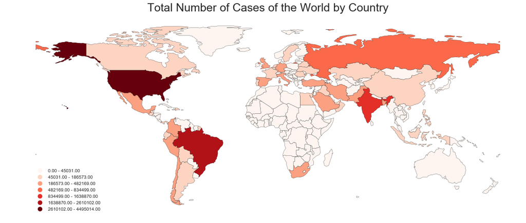

```python
# world map for cases by country
ax = df_by_ctry.plot(column = 'cases',
                cmap='Reds',
                edgecolor='k',
                linewidth = .3,
                figsize=(20,20),
                legend=True,
                scheme='FisherJenks', k=7
                )
ax.set_title('Total Number of Cases of the World by Country', fontdict={'fontsize': 25, 'fontweight': 5}, pad=12)
ax.get_legend().set_bbox_to_anchor((.18, .25))
ax.axis('off');
```

As we can see, most of the countries have total cases of less than 46,000 and they are mostly in Africa along with Australia. However, the three countries with highest number of total cases are the United States, Brazil, and India, respectively with total number of cases ranges from ~ 835,000 to ~ 4,500,000

### Bar Chart of the Total Number of Cases for the World Top Ten Countries

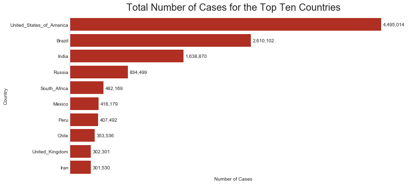

```python
# bar chart of cases for the top 10 countries
top_10 = df_total.sort_values('cases', ascending=False).head(10) # create df of 10 countries with largest number of cases

fig, ax = plt.subplots(1, figsize=(12,6))

ax = sns.barplot(data=top_10, y='country', x='cases', color='#C81C0B')

for i, j in zip(ax.patches, top_10['cases']): # loop for every bar and every case value in top_10 df
    ax.text(i.get_width()+25000, i.get_y()+.50, '{:,}'.format(math.trunc(j)))

    ax.axes.get_xaxis().set_ticks([]) # remove xaxis ticks
ax.spines['right'].set_visible(False) # remove the right spine to prevent annotation overlapping
ax.spines['bottom'].set_visible(False) # remove for better look
ax.spines['top'].set_visible(False) # remove for for better look
ax.set_title('Total Number of Cases for the Top Ten Countries', fontdict = {'fontsize': 20}, pad=12)
ax.set_xlabel('Number of Cases')
ax.set_ylabel('Country');
```

### Map of the World Showing the Total Number of Deaths per Country

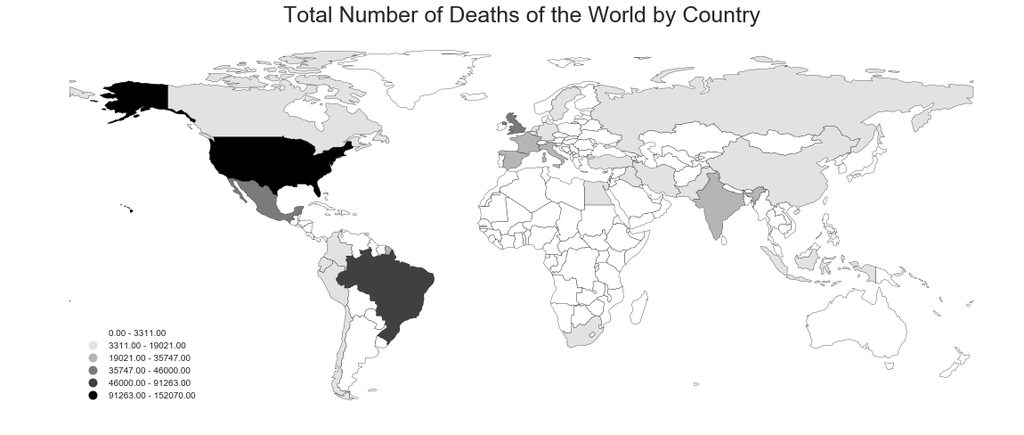

```python
# world map for deaths by country
ax = df_by_ctry.plot(column = 'deaths',
                cmap='Greys',
                edgecolor='k',
                linewidth = .3,
                figsize=(20,20),
                legend=True,
                scheme='FisherJenks', k=6
                )
ax.set_title('Total Number of Deaths of the World by Country', fontdict={'fontsize': 25, 'fontweight': 5}, pad=12)
ax.get_legend().set_bbox_to_anchor((.18, .25))
ax.axis('off');
```

Again, we see most of the countries with less number of total deaths are in Africa along with Australia with total number of 3,311 or less. While the three countries with the highest total number of deaths are the United States, Brazil, and Mexico with a total number ranges from ~ 35,750 to ~ 152,000

### Bar Chart of the Total Number of Deaths for the World Top Ten Countries

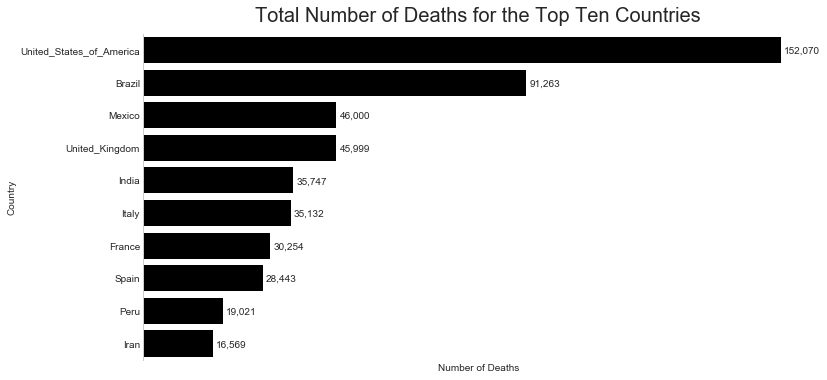

```python
# bar chart of deaths for the top 10 countries
top_10 = df_total.sort_values('deaths', ascending=False).head(10) # create df of 10 countries with largest number of cases

fig, ax = plt.subplots(1, figsize=(12,6))

ax = sns.barplot(data=top_10, y='country', x='deaths', color='k')

for i, j in zip(ax.patches, top_10['deaths']): # loop for every bar and every case value in top_10 df
    ax.text(i.get_width()+750, i.get_y()+.50, '{:,}'.format(math.trunc(j)))

    ax.axes.get_xaxis().set_ticks([]) # remove xaxis ticks
ax.spines['right'].set_visible(False) # remove the right spine to prevent annotation overlapping
ax.spines['bottom'].set_visible(False) # remove for better look
ax.spines['top'].set_visible(False) # remove for for better look
ax.set_title('Total Number of Deaths for the Top Ten Countries', fontdict = {'fontsize': 20}, pad=12)
ax.set_xlabel('Number of Deaths')
ax.set_ylabel('Country');
```

### Map of the World Showing the Case Ratio per Country

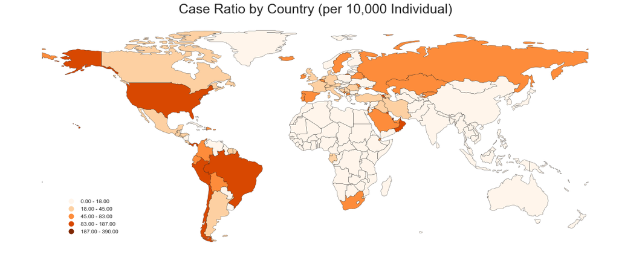

```python
# world map for case_ratio by country
ax = df_by_ctry.plot(column = 'case_ratio',
                cmap='Oranges',
                edgecolor='k',
                linewidth = .3,
                figsize=(20,20),
                legend=True,
                scheme='FisherJenks'
                )
ax.set_title('Case Ratio by Country (per 10,000 Individual)', fontdict={'fontsize': 25, 'fontweight': 5}, pad=12)
ax.get_legend().set_bbox_to_anchor((.18, .25))
ax.axis('off');
```

From the previous map, we see that the case ratio for most of the countries in Africa, Australia, and some part of Asia are the lowest, i.e., 18 per 10,000 individual. On the other hand, United States, Brazil, Chile, and Oman have relatively high case ratio between 83 and 187 per 10,000 individual. For the highest case ratio represented by the darkest color in the legend (from 187 to 390), I don’t seem to find the countries that represent those numbers. One explanation is that those countries are small and not showing up in the map. However, next two slides will have a bar chart for the top ten countries with the highest case ratio where I can locate those countries.

### Bar Chart of the Case Ratio for the World Top Ten Countries

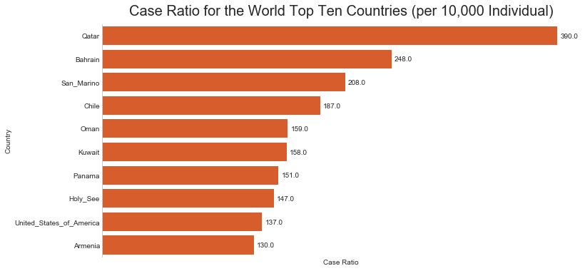

```python
# bar chart of case ratio for the top 10 countries
top_10 = df_total.sort_values('case_ratio', ascending=False).head(10) # create df of 10 countries with largest number of cases

fig, ax = plt.subplots(1, figsize=(12,6))

ax = sns.barplot(data=top_10, y='country', x='case_ratio', color='#F35110')

for i, j in zip(ax.patches, top_10['case_ratio']): # loop for every bar and every case value in top_10 df
    ax.text(i.get_width()+2.5, i.get_y()+.50,round(j,3))

ax.axes.get_xaxis().set_ticks([]) # remove xaxis ticks
ax.spines['right'].set_visible(False) # remove the right spine to prevent annotation overlapping
ax.spines['bottom'].set_visible(False) # remove for better look
ax.spines['top'].set_visible(False) # remove for for better look
ax.set_title('Case Ratio for the World Top Ten Countries (per 10,000 Individual)', fontdict = {'fontsize': 20}, pad=12)
ax.set_xlabel('Case Ratio')
ax.set_ylabel('Country');
```

From the bar chart, we see that countries with the highest case ratio are Qatar, Bahrain, and San Marino

### Map of the World Showing the Death Ratio per Country

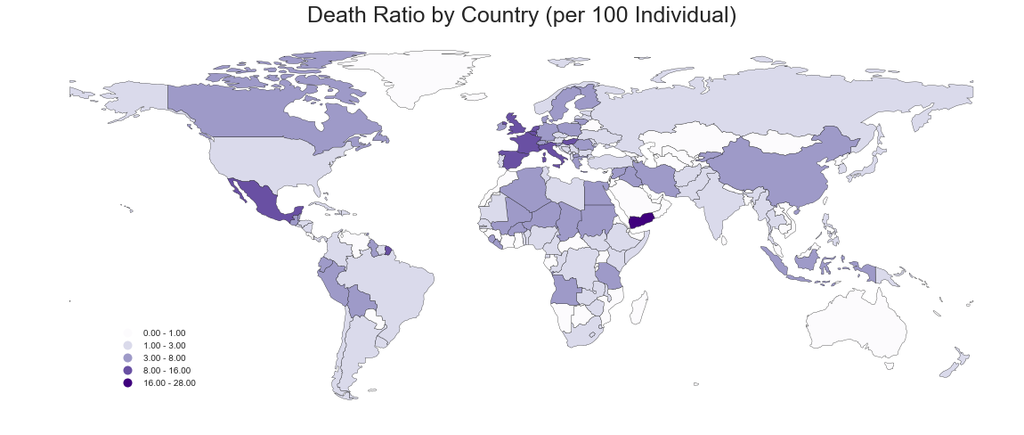

```python
# world map for death_ratio by country
ax = df_by_ctry.plot(column = 'death_ratio',
                cmap='Purples',
                edgecolor='k',
                linewidth = .3,
                figsize=(20,20),
                legend=True,
                scheme='FisherJenks'
                )
ax.set_title('Death Ratio by Country (per 100 Individual)', fontdict={'fontsize': 25, 'fontweight': 5}, pad=12)
ax.get_legend().set_bbox_to_anchor((.18, .25))
ax.axis('off');
```

For death ratio, we see less variance among data comparing to cases, deaths, and case ratio.

### Bar Chart of the Death Ratio for the World Top Ten Countries

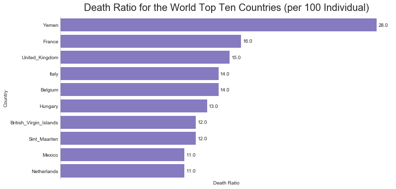

```python
top_10 = df_total.sort_values('death_ratio', ascending=False).head(10) # create df of 10 countries with largest number of cases

fig, ax = plt.subplots(1, figsize=(12,6))

ax = sns.barplot(data=top_10, y='country', x='death_ratio', color='#7E6ECD')

for i, j in zip(ax.patches, top_10['death_ratio']): # loop for every bar and every case value in top_10 df
    ax.text(i.get_width()+.15, i.get_y()+.50, round(j,2))

ax.axes.get_xaxis().set_ticks([]) # remove xaxis ticks
ax.spines['right'].set_visible(False) # remove the right spine to prevent annotation overlapping
ax.spines['bottom'].set_visible(False) # remove for better look
ax.spines['top'].set_visible(False) # remove for for better look
ax.set_title('Death Ratio for the World Top Ten Countries (per 100 Individual)', fontdict = {'fontsize': 20}, pad=12)
ax.set_xlabel('Death Ratio')
ax.set_ylabel('Country');
```

### Line Graph To Show the World Total Daily Cases and Deaths

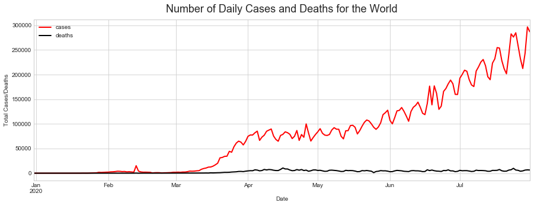

```python
# plot line chart for both daily cases and daily deaths for the world
plt.figure(figsize=(15,5))
df_by_day['cases'].plot(color='r', linewidth=2)
df_by_day['deaths'].plot(color='k', linewidth=2)
plt.title('Number of Daily Cases and Deaths for the World', fontdict = {'fontsize': 18}, pad=12)
plt.xlabel('Date')
plt.ylabel('Total Cases/Deaths')
plt.legend();
```

From the plot above, we can see the number of daily cases and deaths is alternating between high and low. Let me zoon on cases for the last month, i.e., from July 1 to July 31 to have a better look as in the folloiwng slide

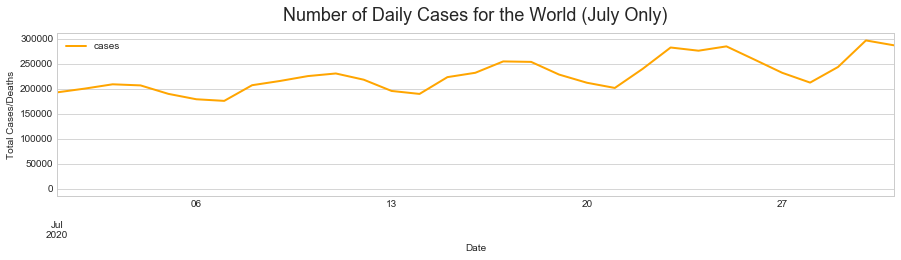

```python
plt.figure(figsize=(15,3))
df_by_day['cases'].plot(color='orange', linewidth=2)
plt.xlabel('Date')
plt.ylabel('Total Cases/Deaths')
plt.legend()
plt.xlim('7/1/2020', '7/31/2020')
plt.title('Number of Daily Cases for the World (July Only)', fontdict = {'fontsize': 18}, pad=12);
```

### Line Graph for the World Total Daily Cases

The graph on the left is a line graph for the world total daily cases. To smooth the line, I plotted a seven-day rolling mean for the world total daily cases, the graph on the right.

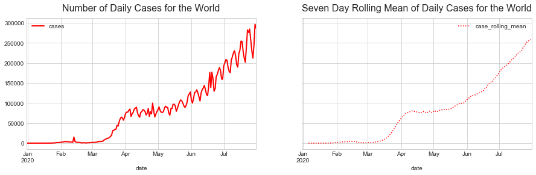

```python
# create two line charts one for the daily cases and the 2nd for daily cases(moving_avg)
fig, (ax1, ax2) = plt.subplots(1,2, figsize=(15,4), sharey=True)

# 1st plot - cases
df_by_day['cases'].plot(ax=ax1, color='r', linewidth=2)
ax1.set_title('Number of Daily Cases for the World', fontdict = {'fontsize': 16}, pad=12)
ax1.legend()

# 2nd plot - rolling mean of cases
df_by_day['case_rolling_mean'].plot(ax=ax2, color='r', linestyle=':')
ax2.set_title('Seven Day Rolling Mean of Daily Cases for the World', fontdict = {'fontsize': 16}, pad=12)
ax2.legend();
```

### Line Graph for the World Total Daily Deaths

Here I have a line graph for the world total daily deaths, the graph on the left. To smooth the line, I plotted a seven-day rolling mean for the world total daily deaths, the graph on the right.

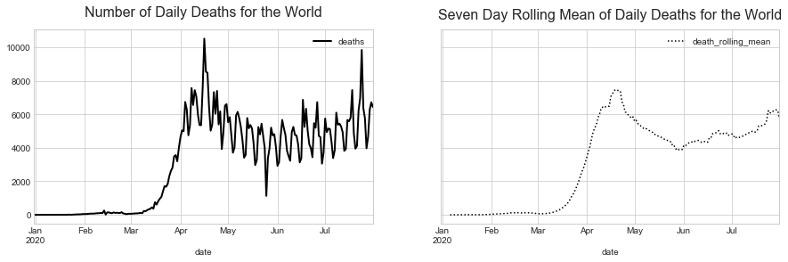

```python
# create two line charts one for the daily deaths and the 2nd for daily deaths(moving_avg)
fig, (ax1, ax2) = plt.subplots(1,2, figsize=(15,4), sharey=True)

# 1st plot - deaths
df_by_day['deaths'].plot(ax=ax1, color='k', linewidth=2)
ax1.set_title('Number of Daily Deaths for the World', fontdict = {'fontsize': 16}, pad=15)
ax1.legend()

# 2nd plot - rolling of deaths
df_by_day['death_rolling_mean'].plot(ax=ax2, color='k', linestyle=':')
ax2.set_title('Seven Day Rolling Mean of Daily Deaths for the World', fontdict = {'fontsize': 16}, pad=12)
ax2.legend();
```

For the world total daily deaths, we see the number of daily deaths has a sharp increase from the mid of March until the mid of April with total deaths around 7500/day. However, the number decreased afterward until June where it started to increase again to reach about 6000 deaths by the end of July. However, we can still assume that the number of deaths is reducing comparing to the increase of the number cases.

## Part 2 - Find the Relationship between the Number of Total Cases and Population Density

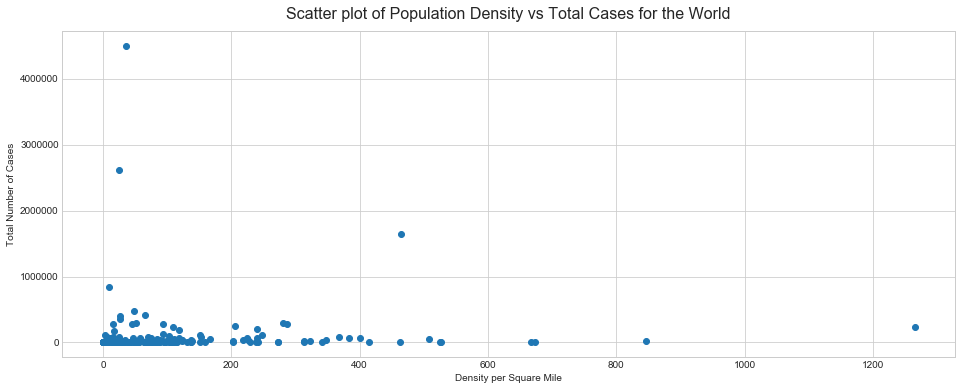

```python
# scatter plot for cases vs density
plt.figure(figsize=(16,6))
plt.scatter(data=df_by_ctry, x='density', y='cases')
plt.ylabel('Total Number of Cases')
plt.xlabel("Density per Square Mile")
plt.title('Scatter plot of Population Density vs Total Cases for the World', fontdict={'fontsize':'16'}, pad=12);
```

From the scatter plot above, we do not seem to have a relationship between population density and the total number of cases. On the contrary, we see two extreme points, the first one with low density but very high number of cases, while, the second point with has very high density but low number of cases. However, there could be many factors that hid the effect of high populated countries on the number of cases, such as curfew, precautions made by people, and so on.

## Part 3 - Explore the Arab world

### Bar Chart of the Total Number of Cases for the Arab World Countries

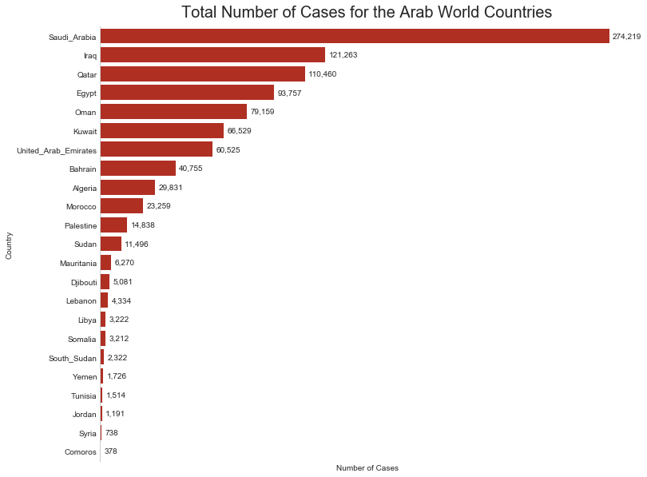

```python
# bar chart of total cases for Arab World countries
fig, ax = plt.subplots(1, figsize=(12,10))

ax = sns.barplot(data= df_arab_by_ctry.sort_values('cases', ascending=False), y='country', x='cases', color='#C81C0B')

for i, j in zip(ax.patches, df_arab_by_ctry.sort_values('cases', ascending=False)['cases']): #loop for every bar and every case value in top_10 df
    ax.text(i.get_width()+2000, i.get_y()+.50, '{:,}'.format(math.trunc(j)))

ax.axes.get_xaxis().set_ticks([]) # remove xaxis ticks
ax.spines['right'].set_visible(False) # remove the right spine to prevent annotation overlapping
ax.spines['bottom'].set_visible(False) # remove for better look
ax.spines['top'].set_visible(False) # remove for for better look
ax.set_title('Total Number of Cases for the Arab World Countries', fontdict = {'fontsize': 20}, pad=12)
ax.set_xlabel('Number of Cases')
ax.set_ylabel('Country');
```

### Bar Chart of the Total Number of Deaths for the Arab World Countries

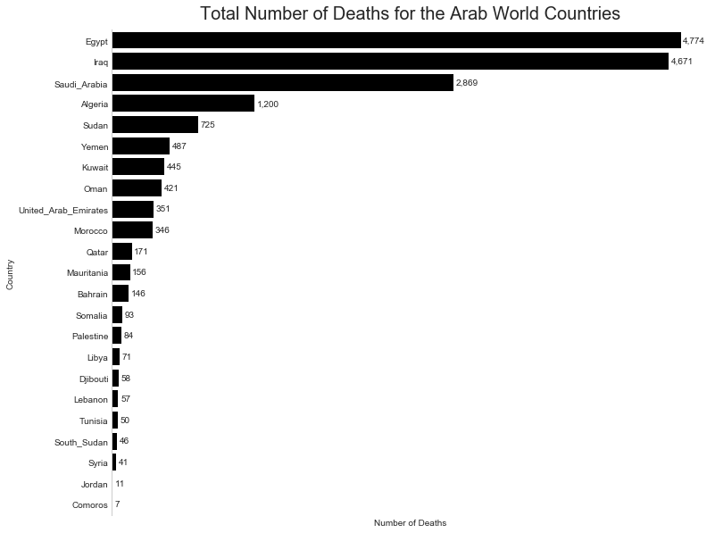

```python
# bar chart of total deaths for Arab World countries
fig, ax = plt.subplots(1, figsize=(12,10))

ax = sns.barplot(data= df_arab_by_ctry.sort_values('deaths', ascending=False), y='country', x='deaths', color='k')

for i, j in zip(ax.patches, df_arab_by_ctry.sort_values('deaths', ascending=False)['deaths']): #loop for every bar and every case value in top_10 df
    ax.text(i.get_width()+20, i.get_y()+.50, '{:,}'.format(math.trunc(j)))

ax.axes.get_xaxis().set_ticks([]) # remove xaxis ticks
ax.spines['right'].set_visible(False) # remove the right spine to prevent annotation overlapping
ax.spines['bottom'].set_visible(False) # remove for better look
ax.spines['top'].set_visible(False) # remove for for better look
ax.set_title('Total Number of Deaths for the Arab World Countries', fontdict = {'fontsize': 20}, pad=12)
ax.set_xlabel('Number of Deaths')
ax.set_ylabel('Country');
```

### Bar Chart of the Case Ratio for the Arab World Countries

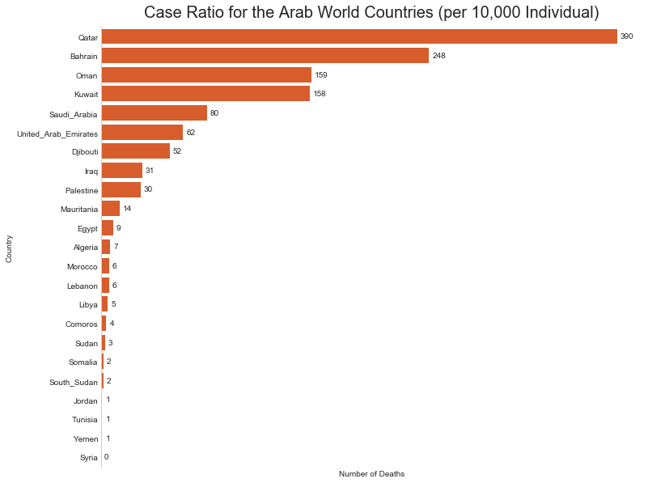

```python
# bar chart of case ratio for Arab World countries
fig, ax = plt.subplots(1, figsize=(12,10))

ax = sns.barplot(data= df_arab_by_ctry.sort_values('case_ratio', ascending=False), y='country', x='case_ratio', color='#F35110')

for i, j in zip(ax.patches, df_arab_by_ctry.sort_values('case_ratio', ascending=False)['case_ratio']): #loop for every bar and every case value in top_10 df
    ax.text(i.get_width()+2.5, i.get_y()+.50, '{:,}'.format(math.trunc(j)))

ax.axes.get_xaxis().set_ticks([]) # remove xaxis ticks
ax.spines['right'].set_visible(False) # remove the right spine to prevent annotation overlapping
ax.spines['bottom'].set_visible(False) # remove for better look
ax.spines['top'].set_visible(False) # remove for for better look
ax.set_title('Case Ratio for the Arab World Countries (per 10,000 Individual)', fontdict = {'fontsize': 20}, pad=12)
ax.set_xlabel('Number of Deaths')
ax.set_ylabel('Country');
```

Interestingly enough, we see the Arab Gulf countries have the highest case ratio starting with Qatar and ending with UAE.

### Bar Chart of the Death Ratio for the Arab World Countries

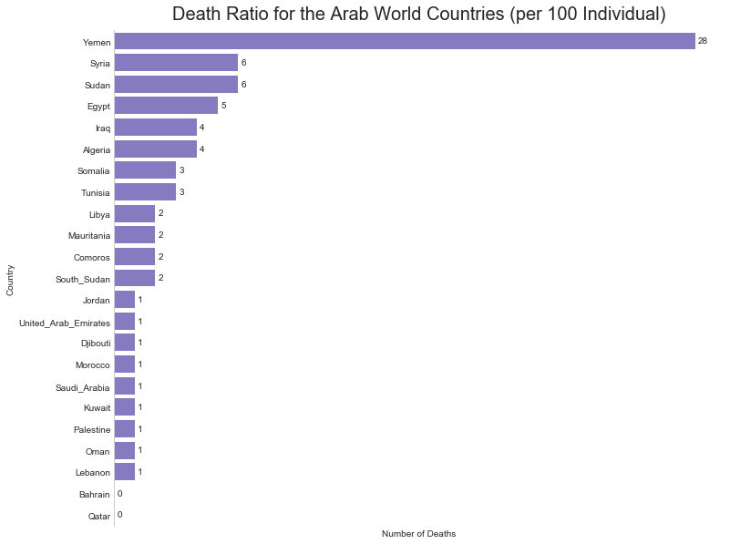

```python
# bar chart of case ratio for Arab World countries
fig, ax = plt.subplots(1, figsize=(12,10))

ax = sns.barplot(data= df_arab_by_ctry.sort_values('death_ratio', ascending=False), y='country', x='death_ratio', color='#7E6ECD')

for i, j in zip(ax.patches, df_arab_by_ctry.sort_values('death_ratio', ascending=False)['death_ratio']): #loop for every bar and every case value in top_10 df
    ax.text(i.get_width()+.15, i.get_y()+.50, '{:,}'.format(math.trunc(j)))

ax.axes.get_xaxis().set_ticks([]) # remove xaxis ticks
ax.spines['right'].set_visible(False) # remove the right spine to prevent annotation overlapping
ax.spines['bottom'].set_visible(False) # remove for better look
ax.spines['top'].set_visible(False) # remove for for better look
ax.set_title('Death Ratio for the Arab World Countries (per 100 Individual)', fontdict = {'fontsize': 20}, pad=12)
ax.set_xlabel('Number of Deaths')
ax.set_ylabel('Country');
```

From the bar chart above we see Yemen is by far has the highest death ratio, not only in the Arab world countries, but also in the entire world. However, Qatar and Bahrain has almost zero death ratio. What interesting is that Qatar has the highest case ratio in the world but they have the lowest death ratio among the Arab world countries. I am not sure how they managed to do that; probably this will need a separate analysis.

### Line Charts of the Total Daily Cases for the Arab World Countries

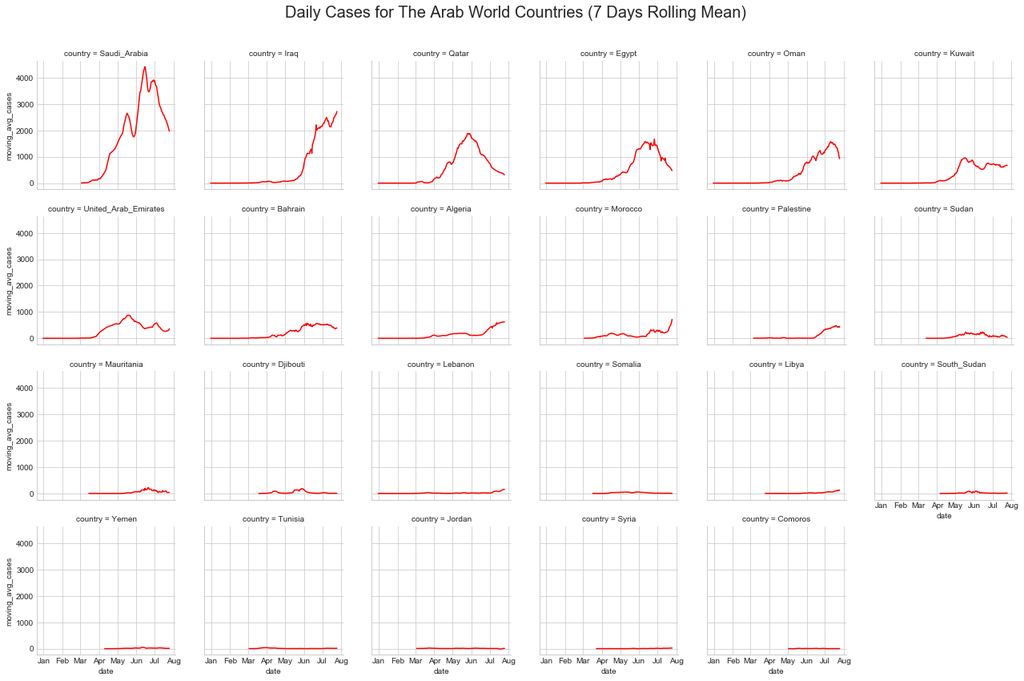

```python
# assign a new column for cases rolling mean for 7 days for each country
df_arab_by_day = df_arab_by_day.assign(moving_avg_cases = df.groupby('country')['cases'].rolling(window=7).mean().reset_index(0, drop=True))

# create FacetGrid for daily cases moving average
order = df_arab_by_day.groupby('country').sum().sort_values('moving_avg_cases', ascending=False).index

g = sns.FacetGrid(df_arab_by_day, col='country', col_wrap=6, col_order=order)
g = g.map(plt.plot, 'date', 'moving_avg_cases', color='r')

locator = mdates.MonthLocator()
formatter = mdates.DateFormatter('%b')

g.axes[0].xaxis.set_major_locator(locator)
g.axes[0].xaxis.set_major_formatter(formatter)

plt.subplots_adjust(top=0.9)
g.fig.suptitle('Daily Cases for The Arab World Countries (7 Days Rolling Mean)', size=20);
```

From the FacetGrid we see most of the Arab world countries are getting better in reducing the number of daily cases except Iraq, Algeria, Morocco, and Palestine with Iraq being the worst. Lebanon and Libya have slight increase in the mid of July

### Line Charts of the Total Daily Deaths for the Arab World Countries

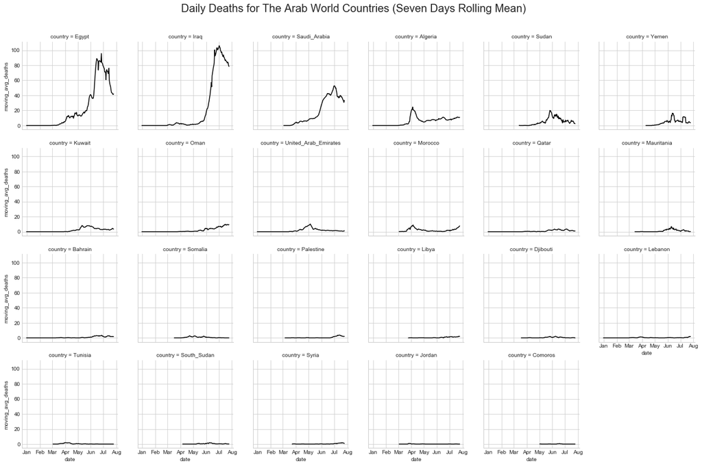

```python
# assign a new column for deaths rolling mean for 7 days for each country
df_arab_by_day = df_arab_by_day.assign(moving_avg_deaths = df.groupby('country')['deaths'].rolling(window=7).mean().reset_index(0, drop=True))

# create FacetGrid for daily deaths moving average
order = df_arab_by_day.groupby('country').sum().sort_values('moving_avg_deaths', ascending=False).index

g = sns.FacetGrid(df_arab_by_day, col='country', col_wrap=6, col_order=order)
g = g.map(plt.plot, 'date', 'moving_avg_deaths', color='k')

locator = mdates.MonthLocator()
formatter = mdates.DateFormatter('%b')

g.axes[0].xaxis.set_major_locator(locator)
g.axes[0].xaxis.set_major_formatter(formatter)

plt.subplots_adjust(top=0.9)
g.fig.suptitle('Daily Deaths for The Arab World Countries (Seven Days Rolling Mean)', size=20);
```

For daily deaths, we some most of the countries have reduced number of daily death after high peaks. However, Algeria and Morocco seem to develop new peaks but it is not clear as the data ends by July

### Line Charts of the Total Daily Cases for the Top-Five Arab Countries

Now, I would like to plot a line graphs for daily cases for the top five arab countries with the highest number of total cases

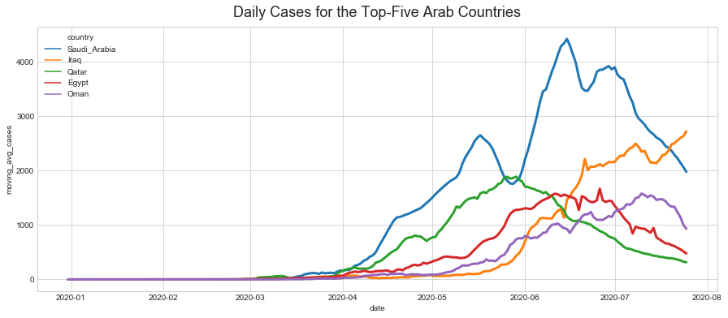

```python
# line graph for the top five Arab countries
plt.figure(figsize=(15,6))
sns.lineplot(x='date', y='moving_avg_cases', hue='country', data=df_arab_by_day, hue_order=arab_top_5, linewidth=3)
plt.title('Daily Cases for the Top-Five Arab Countries', fontdict = {'fontsize':18}, pad=12)
plt.legend(loc=2);
```

From the graph above, we see all the countries seem to better managed the number of daily cases except Iraq, which is heading toward higher daily cases. However, Iraq showed low daily cases from the beginning of the pandemic until the third week of May where it started to develop new cases quickly.